# task 5

```python
#Step 1: Importing required libraries

import pandas as pd
import numpy as np
import seaborn as sns
import matplotlib.pyplot as plt
```

```python
#checking the location of the repository

import os
print(os.getcwd())
```

```
C:\Users\ADMIN\anaconda3\ELEVATE LABS\TASK 5
```

```python
#Step 2:loading the dataset

df = pd.read_csv("train.csv", encoding='ISO-8859-1')
df
```

|  | PassengerId | Survived | Pclass | Name | Sex | Age | SibSp | Parch | Ticket | Fare | Cabin | Embarked |
| --- | --- | --- | --- | --- | --- | --- | --- | --- | --- | --- | --- | --- |
| 0 | 1 | 0 | 3 | Braund, Mr. Owen Harris | male | 22.0 | 1 | 0 | A/5 21171 | 7.2500 | NaN | S |
| 1 | 2 | 1 | 1 | Cumings, Mrs. John Bradley (Florence Briggs Th... | female | 38.0 | 1 | 0 | PC 17599 | 71.2833 | C85 | C |
| 2 | 3 | 1 | 3 | Heikkinen, Miss. Laina | female | 26.0 | 0 | 0 | STON/O2. 3101282 | 7.9250 | NaN | S |
| 3 | 4 | 1 | 1 | Futrelle, Mrs. Jacques Heath (Lily May Peel) | female | 35.0 | 1 | 0 | 113803 | 53.1000 | C123 | S |
| 4 | 5 | 0 | 3 | Allen, Mr. William Henry | male | 35.0 | 0 | 0 | 373450 | 8.0500 | NaN | S |
| ... | ... | ... | ... | ... | ... | ... | ... | ... | ... | ... | ... | ... |
| 886 | 887 | 0 | 2 | Montvila, Rev. Juozas | male | 27.0 | 0 | 0 | 211536 | 13.0000 | NaN | S |
| 887 | 888 | 1 | 1 | Graham, Miss. Margaret Edith | female | 19.0 | 0 | 0 | 112053 | 30.0000 | B42 | S |
| 888 | 889 | 0 | 3 | Johnston, Miss. Catherine Helen "Carrie" | female | NaN | 1 | 2 | W./C. 6607 | 23.4500 | NaN | S |
| 889 | 890 | 1 | 1 | Behr, Mr. Karl Howell | male | 26.0 | 0 | 0 | 111369 | 30.0000 | C148 | C |
| 890 | 891 | 0 | 3 | Dooley, Mr. Patrick | male | 32.0 | 0 | 0 | 370376 | 7.7500 | NaN | Q |

891 rows × 12 columns

```python
#Step 3:Standardize column names (lowercase and replace spaces with underscores)

df.columns = df.columns.str.strip().str.lower().str.replace(" ", "_")
```

```python
# Step 4: View basic info

print("Initial dataset shape:", df.shape)
print("\nColumn-wise missing values:\n", df.isnull().sum())
```

```
Initial dataset shape: (891, 12)

Column-wise missing values:
 passengerid      0
survived         0
pclass           0
name             0
sex              0
age            177
sibsp            0
parch            0
ticket           0
fare             0
cabin          687
embarked         2
dtype: int64
```

```python
#Step 5:removing duplicates

df = df.drop_duplicates()
print("\nShape after removing duplicates:", df.shape)
```

```
Shape after removing duplicates: (891, 12)
```

```python
#Step 6:Fill missing Age with median or mean

df['age'].fillna(df['age'].median(), inplace=True)
df.isnull().sum()
```

```
passengerid      0
survived         0
pclass           0
name             0
sex              0
age              0
sibsp            0
parch            0
ticket           0
fare             0
cabin          687
embarked         2
dtype: int64
```

```python
#Step 7: Fill missing Embarked with the most frequent value

df['embarked'].fillna(df['embarked'].mode()[0], inplace=True)
df.isnull().sum()
```

```
passengerid      0
survived         0
pclass           0
name             0
sex              0
age              0
sibsp            0
parch            0
ticket           0
fare             0
cabin          687
embarked         0
dtype: int64
```

```python
#Step 8: relacing missing values of cabin with 'unknown'

df['cabin'] = df['cabin'].fillna("unknown")
df.isnull().sum()
```

```
passengerid    0
survived       0
pclass         0
name           0
sex            0
age            0
sibsp          0
parch          0
ticket         0
fare           0
cabin          0
embarked       0
dtype: int64
```

```python
# Step 10: Export the cleaned dataset to a new CSV file


df.to_csv("train_cleaned.csv", index=False)
print("\nCleaned dataset saved as 'train_cleaned.csv'")
```

```
Cleaned dataset saved as 'train_cleaned.csv'
```

```python
#Step 11:loading the cleaned dataset

df1 = pd.read_csv("train_cleaned.csv", encoding='ISO-8859-1')
df1
```

|  | passengerid | survived | pclass | name | sex | age | sibsp | parch | ticket | fare | cabin | embarked |
| --- | --- | --- | --- | --- | --- | --- | --- | --- | --- | --- | --- | --- |
| 0 | 1 | 0 | 3 | Braund, Mr. Owen Harris | male | 22.0 | 1 | 0 | A/5 21171 | 7.2500 | unknown | S |
| 1 | 2 | 1 | 1 | Cumings, Mrs. John Bradley (Florence Briggs Th... | female | 38.0 | 1 | 0 | PC 17599 | 71.2833 | C85 | C |
| 2 | 3 | 1 | 3 | Heikkinen, Miss. Laina | female | 26.0 | 0 | 0 | STON/O2. 3101282 | 7.9250 | unknown | S |
| 3 | 4 | 1 | 1 | Futrelle, Mrs. Jacques Heath (Lily May Peel) | female | 35.0 | 1 | 0 | 113803 | 53.1000 | C123 | S |
| 4 | 5 | 0 | 3 | Allen, Mr. William Henry | male | 35.0 | 0 | 0 | 373450 | 8.0500 | unknown | S |
| ... | ... | ... | ... | ... | ... | ... | ... | ... | ... | ... | ... | ... |
| 886 | 887 | 0 | 2 | Montvila, Rev. Juozas | male | 27.0 | 0 | 0 | 211536 | 13.0000 | unknown | S |
| 887 | 888 | 1 | 1 | Graham, Miss. Margaret Edith | female | 19.0 | 0 | 0 | 112053 | 30.0000 | B42 | S |
| 888 | 889 | 0 | 3 | Johnston, Miss. Catherine Helen "Carrie" | female | 28.0 | 1 | 2 | W./C. 6607 | 23.4500 | unknown | S |
| 889 | 890 | 1 | 1 | Behr, Mr. Karl Howell | male | 26.0 | 0 | 0 | 111369 | 30.0000 | C148 | C |
| 890 | 891 | 0 | 3 | Dooley, Mr. Patrick | male | 32.0 | 0 | 0 | 370376 | 7.7500 | unknown | Q |

891 rows × 12 columns

```python
#Step 12:Standardize column names (lowercase and replace spaces with underscores)

df1.columns = df1.columns.str.strip().str.lower().str.replace(" ", "_")
```

```python
df1.head()
```

|  | passengerid | survived | pclass | name | sex | age | sibsp | parch | ticket | fare | cabin | embarked |
| --- | --- | --- | --- | --- | --- | --- | --- | --- | --- | --- | --- | --- |
| 0 | 1 | 0 | 3 | Braund, Mr. Owen Harris | male | 22.0 | 1 | 0 | A/5 21171 | 7.2500 | unknown | S |
| 1 | 2 | 1 | 1 | Cumings, Mrs. John Bradley (Florence Briggs Th... | female | 38.0 | 1 | 0 | PC 17599 | 71.2833 | C85 | C |
| 2 | 3 | 1 | 3 | Heikkinen, Miss. Laina | female | 26.0 | 0 | 0 | STON/O2. 3101282 | 7.9250 | unknown | S |
| 3 | 4 | 1 | 1 | Futrelle, Mrs. Jacques Heath (Lily May Peel) | female | 35.0 | 1 | 0 | 113803 | 53.1000 | C123 | S |
| 4 | 5 | 0 | 3 | Allen, Mr. William Henry | male | 35.0 | 0 | 0 | 373450 | 8.0500 | unknown | S |

```python
df1.describe()
```

|  | passengerid | survived | pclass | age | sibsp | parch | fare |
| --- | --- | --- | --- | --- | --- | --- | --- |
| count | 891.000000 | 891.000000 | 891.000000 | 891.000000 | 891.000000 | 891.000000 | 891.000000 |
| mean | 446.000000 | 0.383838 | 2.308642 | 29.361582 | 0.523008 | 0.381594 | 32.204208 |
| std | 257.353842 | 0.486592 | 0.836071 | 13.019697 | 1.102743 | 0.806057 | 49.693429 |
| min | 1.000000 | 0.000000 | 1.000000 | 0.420000 | 0.000000 | 0.000000 | 0.000000 |
| 25% | 223.500000 | 0.000000 | 2.000000 | 22.000000 | 0.000000 | 0.000000 | 7.910400 |
| 50% | 446.000000 | 0.000000 | 3.000000 | 28.000000 | 0.000000 | 0.000000 | 14.454200 |
| 75% | 668.500000 | 1.000000 | 3.000000 | 35.000000 | 1.000000 | 0.000000 | 31.000000 |
| max | 891.000000 | 1.000000 | 3.000000 | 80.000000 | 8.000000 | 6.000000 | 512.329200 |

```python
df1.mode()
```

|  | passengerid | survived | pclass | name | sex | age | sibsp | parch | ticket | fare | cabin | embarked |
| --- | --- | --- | --- | --- | --- | --- | --- | --- | --- | --- | --- | --- |
| 0 | 1 | 0.0 | 3.0 | Abbing, Mr. Anthony | male | 28.0 | 0.0 | 0.0 | 1601 | 8.05 | unknown | S |
| 1 | 2 | NaN | NaN | Abbott, Mr. Rossmore Edward | NaN | NaN | NaN | NaN | 347082 | NaN | NaN | NaN |
| 2 | 3 | NaN | NaN | Abbott, Mrs. Stanton (Rosa Hunt) | NaN | NaN | NaN | NaN | CA. 2343 | NaN | NaN | NaN |
| 3 | 4 | NaN | NaN | Abelson, Mr. Samuel | NaN | NaN | NaN | NaN | NaN | NaN | NaN | NaN |
| 4 | 5 | NaN | NaN | Abelson, Mrs. Samuel (Hannah Wizosky) | NaN | NaN | NaN | NaN | NaN | NaN | NaN | NaN |
| ... | ... | ... | ... | ... | ... | ... | ... | ... | ... | ... | ... | ... |
| 886 | 887 | NaN | NaN | de Mulder, Mr. Theodore | NaN | NaN | NaN | NaN | NaN | NaN | NaN | NaN |
| 887 | 888 | NaN | NaN | de Pelsmaeker, Mr. Alfons | NaN | NaN | NaN | NaN | NaN | NaN | NaN | NaN |
| 888 | 889 | NaN | NaN | del Carlo, Mr. Sebastiano | NaN | NaN | NaN | NaN | NaN | NaN | NaN | NaN |
| 889 | 890 | NaN | NaN | van Billiard, Mr. Austin Blyler | NaN | NaN | NaN | NaN | NaN | NaN | NaN | NaN |
| 890 | 891 | NaN | NaN | van Melkebeke, Mr. Philemon | NaN | NaN | NaN | NaN | NaN | NaN | NaN | NaN |

891 rows × 12 columns

```python
df1.info()
```

```
<class 'pandas.core.frame.DataFrame'>
RangeIndex: 891 entries, 0 to 890
Data columns (total 12 columns):
 #   Column       Non-Null Count  Dtype
---  ------       --------------  -----
 0   passengerid  891 non-null    int64
 1   survived     891 non-null    int64
 2   pclass       891 non-null    int64
 3   name         891 non-null    object
 4   sex          891 non-null    object
 5   age          891 non-null    float64
 6   sibsp        891 non-null    int64
 7   parch        891 non-null    int64
 8   ticket       891 non-null    object
 9   fare         891 non-null    float64
 10  cabin        891 non-null    object
 11  embarked     891 non-null    object
dtypes: float64(2), int64(5), object(5)
memory usage: 83.7+ KB
```

```python
#converting the columns Sex and Title from objects to category

df1['sex'] = df1['sex'].astype('category')
df1['embarked'] = df1['embarked'].astype('category')
```

# Univariate Analysis

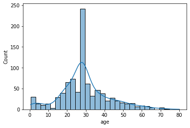

```python
# Numerical: Histograms


sns.histplot(df1['age'], kde=True)
```

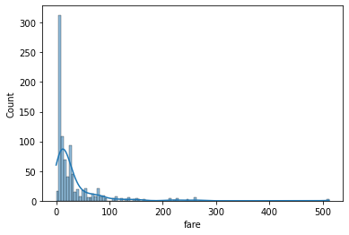

```python
sns.histplot(df1['fare'], kde=True)
```

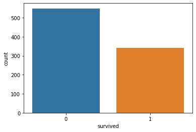

```python
#Categorical: Countplots

sns.countplot(x='survived', data=df1)
```

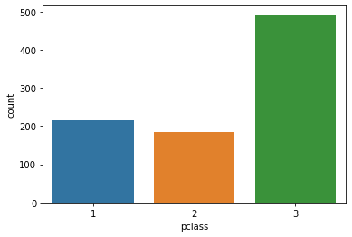

```python
sns.countplot(x='pclass', data=df1)
```

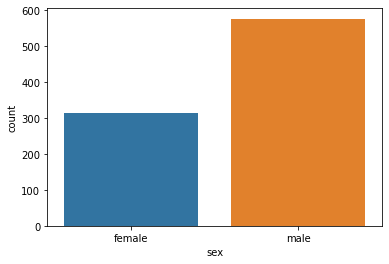

```python
sns.countplot(x='sex', data=df1)
```

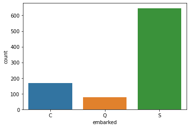

```python
sns.countplot(x='embarked', data=df1)
```

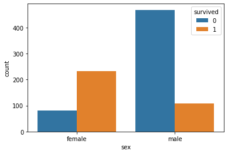

```python
sns.countplot(x='sex', hue='survived', data=df1)
```

# Bivariate Analysis

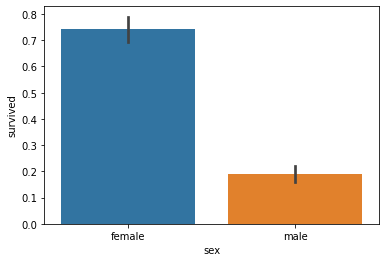

```python
# Categorical vs Target (Survived)

sns.barplot(x='sex', y='survived', data=df1)
```

y='Survived' is binary (0 = died, 1 = survived)

So barplot calculates average of 0s and 1s

This average = percentage of people who survived

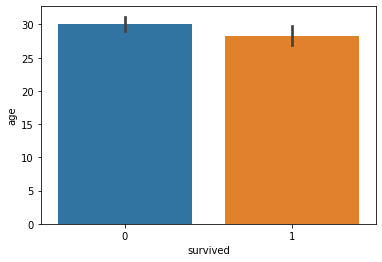

```python
sns.barplot(x='survived', y='age', data=df1)
```

The average age of people who did not survive is between 29 and 30 and the average age of people who survived is between 28 and 29

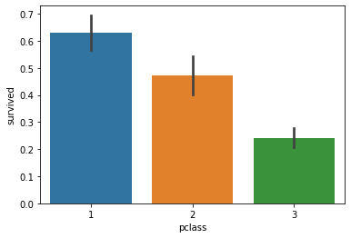

```python
sns.barplot(x='pclass', y='survived', data=df1)
```

The passengers from class 1 had 63% survival rate, those from class 2 had 48% survival rate and those from class 3 had 24% survival rate

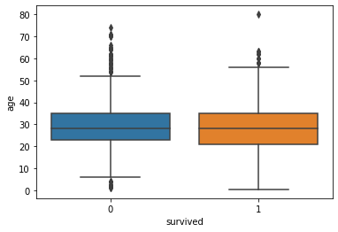

```python
# Numerical vs Target

sns.boxplot(x='survived', y='age', data=df1)
```

Both groups have outliers, especially above age 60 Some elderly people in both groups, but more elderly non-survivors

Minimum age is close to 0 in both groups Max age for survivors is slightly higher (80) than for non-survivors (70+)

- Younger people were slightly more likely to survive
- There’s a wide age distribution in both groups, but survivors lean younger
- Elderly passengers were more likely not to survive
- Outliers (elderly survivors) exist but are rare as compared to elderly non-survivors

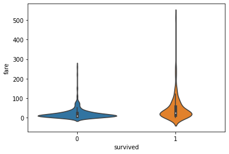

```python
sns.violinplot(x='survived', y='fare', data=df1)
```

For Survived = 0 (Did not survive): Most passengers paid low fares (clustered near the bottom). The distribution is tightly packed, with a few outliers who paid higher fares. There’s less variation in fare amounts among those who didn’t survive.

For Survived = 1 (Survived): There's greater spread in fare values. While many survivors also paid low fares, there is a noticeable tail extending upward, indicating some survivors paid very high fares (possibly from 1st class). This group has more variance and outliers, showing a wider range of fares.

# Multivariate Analysis

Heatmap (Correlation)

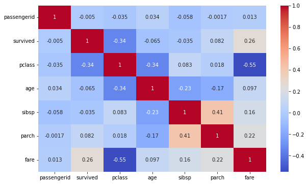

```python
plt.figure(figsize=(10,6))
sns.heatmap(df1.corr(), annot=True, cmap='coolwarm')
```

Fare and Pclass are important features that influenced survival. Age, SibSp, and Parch have weaker influence individually, but may matter when combined (feature interactions). This heatmap backs up your visualizations and can help guide feature selection or modeling choices if you're building a prediction model.

Pairplot

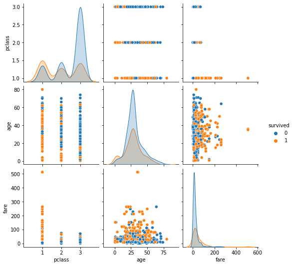

```python
sns.pairplot(df1[['survived', 'pclass', 'age', 'fare']], hue='survived')
```

Age: Both survived and not survived are centered around 20–30. Slightly more orange at younger ages — younger passengers had slightly higher chances.

Fare: Survivors (orange) show a longer tail toward high fares — again showing that higher fares = better survival odds.

➤Pclass vs Age: Clear vertical clustering (1, 2, 3) due to Pclass being categorical. More orange in 1st class, even among older passengers.

➤ Pclass vs Fare: Strong separation: 1st class fares are significantly higher. Most high-fare outliers are survivors.

➤ Age vs Fare: No strong linear relationship. Survivors spread across all ages and fares, but those with very high fares mostly survived.

Pclass and Fare show a strong relationship with survival.

Age has some influence (especially for very young), but not as strong.

There’s multicollinearity between Pclass and Fare, so in modeling, you might consider using just one or applying dimensionality reduction.

# Survival Rate Analysis

```python
survival_rate = df1.groupby('sex')['survived'].mean()
print(survival_rate)
```

```
sex
female    0.742038
male      0.188908
Name: survived, dtype: float64
```

# Class-wise Age Distribution

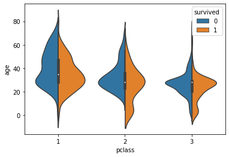

```python
sns.violinplot(x='pclass', y='age', hue='survived', data=df1, split=True)
```

Pclass 1 (left):

- Ages are spread widely, especially for non-survivors (blue).
- Slightly more survivors (orange) around the 30–50 age range.
- Survival and death occurred across all ages — survival not sharply age-dependent here.

Pclass 2 (middle):

- More balance between survival and non-survival.
- Survivors slightly cluster around age 20–40.
- Younger adults in 2nd class had moderate survival chances.

Pclass 3 (right):

- The largest class, with more non-survivors (blue).
- Survivors (orange) are more concentrated in younger age groups, especially kids and young adults.
- Suggests young 3rd class passengers had higher chances of survival than older ones.

Class matters — 1st class had better chances across all ages.

Younger passengers in 3rd class were more likely to survive than older ones.

Age and survival correlation depends heavily on Pclass — strong interaction effect.

# Compare Survived vs Not-Survived Subsets

```python
df1[df1['survived']==1].describe()
df1[df1['survived']==0].describe()
```

[output not shown]

|  | passengerid | survived | pclass | age | sibsp | parch | fare |
| --- | --- | --- | --- | --- | --- | --- | --- |
| count | 549.000000 | 549.0 | 549.000000 | 549.000000 | 549.000000 | 549.000000 | 549.000000 |
| mean | 447.016393 | 0.0 | 2.531876 | 30.028233 | 0.553734 | 0.329690 | 22.117887 |
| std | 260.640469 | 0.0 | 0.735805 | 12.499986 | 1.288399 | 0.823166 | 31.388207 |
| min | 1.000000 | 0.0 | 1.000000 | 1.000000 | 0.000000 | 0.000000 | 0.000000 |
| 25% | 211.000000 | 0.0 | 2.000000 | 23.000000 | 0.000000 | 0.000000 | 7.854200 |
| 50% | 455.000000 | 0.0 | 3.000000 | 28.000000 | 0.000000 | 0.000000 | 10.500000 |
| 75% | 675.000000 | 0.0 | 3.000000 | 35.000000 | 1.000000 | 0.000000 | 26.000000 |
| max | 891.000000 | 0.0 | 3.000000 | 74.000000 | 8.000000 | 6.000000 | 263.000000 |